# Estatística Computacional

Tópico 8

## Pacotes usados nessa semana

```r
set.seed(12345)
library(readxl)
library(readODS)
library(nortest)
library(qqplotr)
library(ggthemes)
library(patchwork)
library(modelr)
library(randtests)
library(broom)
library(glue)
# instale com remotes::install_github("gilberto-sassi/statBasics")
library(statBasics)
library(bootstrap)
library(infer)
library(tidyverse)
```

## Bootstrap, Jackknife e Validação Cruzada

## Bootstrap

**Ideia:** Usar a funções de distribuição acumulada empírica para imitar geração de valores da população.

- Nenhuma suposição paramétrica é feita sobre a população
- Usamos a função de distribuição acumulada empírica para imitar a geração de amostras pseudo-aleatórias
- Gerar \(B\) amostras *bootstrap*: \(\mathbf{x}_1, \dots, \mathbf{x}_B\)
- Criamos \(B\) replicações *bootstrap*: \(\hat\theta_b^{\star} = t(\mathbf{x}_b^{\star}), b = 1, \dots, B\)
- Usamos \(\hat\theta^{\star b}, b=1, \dots, B\) para estudar a distribuição de \(\hat\theta\)
- Usar \(B\) tão grande quanto for possível
- Geralmente para aproximar a variância de estimador, e intervalos de confiança

## Variância de estimador – bootstrap

Seja \(T = g(X_1, \dots, X_n)\) um estimador \(\theta\) com \(X_i \sim F\), e \(V_F(T)\) é a variança de \(T\).

**Ideia:** Aproximamos \(V_F(T)\) com \(V_\hat{F}(T)\), e aproximamos \(V_\hat{F}(T)\) com simulação de monte carlo.

Note que:

1. \(\hat{F}\) é uma Função de Distribuição Acumulada de uma variável aleatória discreta
2. \(\hat{F}\) tem suporte \(\{x_1, \dots, x_n\}\), com função de probabilidade \(f(x_i) = \frac{1}{n}, i=1, \dots, n\)
3. Por causa de 1. e 2., para gerar uma amostra de \(\hat{F}\) basta sortear valores de \(\{x_1, \dots, x_n\}\) com reposição.

Recomendação: usar \(50 \leq B \leq 200\).

## Variância de estimador – bootstrap

Lembre que \(\bar{X} \sim N(\mu, \frac{\sigma^2}{n})\). Como exemplo, vamos assumir que \(\mu = 5\), \(\sigma^2 = 2\) e \(n = 25\).

```r
amostra <- rnorm(25, mean = 5, sd = sqrt(2))
amostras_bootstrap <- seq_len(200) |>
  map(~ sample(amostra, length(amostra), replace = T))
replicacoes_boostrap <- amostras_bootstrap |> map_dbl(~ mean(.x))
variancia_bowley <- var(replicacoes_boostrap)
variancia_bowley
```

```
## [1] 0.0730862
```

## Variância de estimador – bootstrap

Vamos estimar a variância do estimador do coeficiente de Bowley, \(B = \frac{q_3 - 2 \cdot q_2 + q_1}{q_3 - q_1}\), em que \(q_1\), \(q_2\) e \(q_3\) são o primeiro, segundo e o terceiro quartil, para a variável `hp` do conjunto de dados `mtcars`.

```r
dados <- read_csv2("data/raw/mtcars.csv")
bowley <- function(x) {
  q1 <- quantile(x, probs = 0.25)
  q2 <- quantile(x, probs = 0.5)
  q3 <- quantile(x, probs = 0.75)
  (q3 - 2 * q2 + q1) / (q3 - q1)
}
variancia_bowley <- seq_len(200) |>
  map(~ sample(dados$hp, length(dados$hp), replace = T)) |>
  map_dbl(~ bowley(.x)) |>
  var()
variancia_bowley
```

```
## [1] 0.1532168
```

## Vício do estimador – bootstrap

Seja \(T = g(X_1, \dots, X_n)\) um estimador \(\theta\) com \(X_i \sim F\), e \(V_F(T)\) é a variança de \(T\).

**Ideia:** Aproximamos \(E_F(T)\) com \(E_\hat{F}(T)\), e aproximamos \(E_\hat{F}(T)\) com simulação de monte carlo. Consequentemente, podemos aproximar do vício \(T\) por \(\widehat{bias} \approx \bar{\hat\theta^\star} - \hat{\theta}\), em que \(\bar{\hat\theta^\star}\) é uma aproximação de \(E_F(T)\).

Note que:

1. \(\hat{F}\) é uma Função de Distribuição Acumulada de uma variável aleatória discreta
2. \(\hat{F}\) tem suporte \(\{x_1, \dots, x_n\}\), com função de probabilidade \(f(x_i) = \frac{1}{n}, i=1, \dots, n\)
3. Por causa de 1. e 2., para gerar uma amostra de \(\hat{F}\) basta sortear valores de \(\{x_1, \dots, x_n\}\) com reposição.

Recomendação: usar \(B \geq 400\).

## Vício do estimador – bootstrap

Lembre que \(\bar{X} \sim N(\mu, \frac{\sigma^2}{n})\). Como exemplo, vamos assumir que \(\mu = 5\), \(\sigma^2 = 2\) e \(n = 25\).

```r
amostra <- rnorm(25, mean = 5, sd = sqrt(2))
media_bootstrap <- seq_len(500) |>
  map(~ sample(amostra, length(amostra), replace = T)) |>
  map_dbl(~ mean(.x)) |>
  mean()
vicio <- media_bootstrap - mean(amostra)
vicio
```

```
## [1] 0.00457422
```

## Vício do estimador – bootstrap

Vamos estimar o vício do estimador do coeficiente de Bowley, \(B = \frac{q_3 - 2 \cdot q_2 + q_1}{q_3 - q_1}\), em que \(q_1\), \(q_2\) e \(q_3\) são o primeiro, segundo e o terceiro quartil, para a variável `hp` do conjunto de dados `mtcars`.

```r
dados <- read_csv2("data/raw/mtcars.csv")
amostra <- dados$hp
media_bootstrap <- seq_len(500) |>
  map(~ sample(amostra, length(amostra), replace = T)) |>
  map_dbl(~ bowley(.x)) |>
  mean()
vicio <- media_bootstrap - bowley(amostra)
vicio
```

```
##        75%
## -0.1102563
```

## Intervalo de confiança – bootstrap

### **Método:** intervalo de confiança `t`

Seja \(T = g(X_1, \dots, X_n)\) um estimador \(\theta\) com \(X_i \sim F\). O intervalo de confiança pode ser calculado por \(IC(\theta, \gamma = 1- \alpha) = \left( -t_{1-\frac{\alpha}{2}; B-1} dp_{\hat{\theta}} + \hat\theta; t_{1-\frac{\alpha}{2}; B-1} dp_{\hat{\theta}} + \hat\theta \right)\), em que \(t_{1-\frac{\alpha}{2}; B-1}\) é quantil de ordem \(1 - \frac{alpha}{2}\) da distribuição t-Student com \(B-1\) graus de liberdade, e \(dp_{\hat{\theta}}\) é desvio padrão bootstrap do estimador \(\hat\theta\).

```r
amostra <- read_csv2("data/raw/mtcars.csv")$hp
B <- 200
dp_boot <- seq_len(B) |>
  map(~ sample(amostra, length(amostra), replace = T)) |>
  map_dbl(~ bowley(.x)) |>
  sd()
quantil <- qt(0.975, df = B - 1)
glue("Limite inferior: {-quantil * dp_boot + bowley(amostra)}
Limite superior: {quantil * dp_boot + bowley(amostra)}")
```

```
## Limite inferior: -0.430562031357789
## Limite superior: 1.16110095351348
```

## Intervalo de confiança – bootstrap

### **Método:** percentil

Seja \(T = g(X_1, \dots, X_n)\) um estimador \(\theta\) com \(X_i \sim F\). O intervalo de confiança pode ser calculado por \(IC(\theta, \gamma = 1- \alpha) = \left(\hat{q}_\star\left( \frac{\alpha}{2}\right); \hat{q}_\star\left(1- \frac{\alpha}{2}\right) \right)\), em que \(\hat{q}_\star\left( \frac{\alpha}{2}\right)\) é o quantil de ordem \(\frac{\alpha}{2}\) e \(\hat{q}_\star\left(1- \frac{\alpha}{2}\right)\) é o quantil de ordem \(1-\frac{\alpha}{2}\) das replicações *bootstrap* \(\theta_1^\star, \dots, \theta_B^\star\).

```r
amostra <- read_csv2("data/raw/mtcars.csv")$hp
B <- 200 # nolint
replicacoes_bootstrap <- seq_len(B) |>
  map(~ sample(amostra, length(amostra), replace = T)) |>
  map_dbl(~ bowley(.x))
glue("Limite inferior: {quantile(replicacoes_bootstrap, probs = 0.025)}
Limite superior: {quantile(replicacoes_bootstrap, probs = 0.975)}")
```

```
## Limite inferior: -0.853046218487395
## Limite superior: 0.832373032373033
```

## Intervalo de confiança – bootstrap

### **Método:** intervalo pivotal

#### No mundo ideial

**Definição:** Seja \(\hat\theta = T_n = g(X_1, \dots, X_n)\) um estimador \(\theta\). Chamamos \(R_n = \hat\theta - \theta\) de pivô.

Seja \(H(x)\) a função de distribuição acumulada do pivô definido na definição acima, \(H(x) = P\left(R_n \leq x\right)\), e considere \[ \begin{split} a &= \hat\theta - H^{-1}\left(1-\frac{\alpha}{2}\right),\\ b &= \hat\theta - H^{-1}\left(\frac{\alpha}{2}\right), \end{split} \] em que \(H^{-1}\left(\frac{\alpha}{2}\right)\) é o quantil de ordem \(\frac{\alpha}{2}\) de \(R_n\), e \(H^{-1}\left(1-\frac{\alpha}{2}\right)\) de ordem \(1-\frac{\alpha}{2}\) de \(R_n\). Então, o intervalo de confiança é dado por \[ \begin{split} IC(\theta, \gamma = 1 - \alpha) = (a, b). \end{split} \]

Note que

\[ \begin{split} P\left(a \leq \theta \leq b\right) &= P\left(a - \hat\theta \leq \theta - \hat\theta \leq b -\hat\theta \right)\\ &= P\left( \hat\theta - b \leq \hat\theta - \theta \leq \hat\theta - a \right)\\ &= H(\hat\theta - a) - H(\hat\theta -b)\\ &= 1 - \frac{\alpha}{2} - \frac{\alpha}{2}\\ &= 1 - \alpha \end{split} \]

**Problema:** Difícil, ou mesmo impossível, estimar \(H\).

## Intervalo de confiança – bootstrap

### **Método:** intervalo pivotal

**Aproximando \(H\):** wConsidere \(\hat\theta_1^\star, \dots, \hat\theta_B^\star\) replicações bootstrap de \(\hat\theta\), então podemos aproximar \(H\) por \[ \hat{H}(x) = \frac{\sum_{b=1}^{B} I\left(\hat{R}_b^\star \leq x\right)}{B}, \] em que \(I\left( \hat{R}_b^\star \leq x \right) = \begin{cases} 1, & \hat{R}_b^\star \leq x\\ 0, & \hat{R}_b^\star > x \end{cases}\), e \(\hat{R}_b^\star = \hat\theta_b^\star - \hat\theta\).

Seja \(\hat{H}^{-1}(p)\) é o quantil de ordem \(p\) de \(\{\hat{R}_1^\star, \dots, \hat{R}_B^\star\} = \{\hat\theta_1 - \hat\theta, \dots, \hat\theta_B - \hat\theta\}\), e note que \(\hat{H}^{-1}(p)= \hat{q}^\star(p) - \hat\theta\) onde \(\hat{q}^\star(p)\) é quantil de ordem \(p\) de \(\{\hat{\theta}_1, \dots, \hat\theta_B\}\).

\[ \begin{cases} \hat{a} = \hat\theta - \hat{H}^{-1}\left(1 - \frac{\alpha}{2}\right) = \hat\theta - \left(\hat{q}^\star\left(1 - \frac{\alpha}{2}\right) - \hat\theta \right) = 2\hat\theta - \hat{q}^\star\left(1 - \frac{\alpha}{2}\right)\\ \hat{b} = \hat\theta - \hat{H}^{-1}\left(\frac{\alpha}{2}\right) = \hat\theta - \left(\hat{q}^\star\left(\frac{\alpha}{2}\right) - \hat\theta \right) = 2\hat\theta - \hat{q}^\star\left(\frac{\alpha}{2}\right) \end{cases} \]

## Intervalo de confiança – bootstrap

### **Método:** intervalo pivotal

```r
amostra <- read_csv2("data/raw/mtcars.csv")$hp
B <- 200 # nolint
replicacoes_bootstrap <- seq_len(B) |>
  map(~ sample(amostra, length(amostra), replace = T)) |>
  map_dbl(~ bowley(.x))
glue("Limite inferior: {2 * bowley(amostra) - quantile(replicacoes_bootstrap, probs = 0.975)}
Limite superior: {2 * bowley(amostra) - quantile(replicacoes_bootstrap, probs = 0.025)}")
```

```
## Limite inferior: -0.0744129678786758
## Limite superior: 1.48592628257931
```

### Convergência

É possível provar que \(\lim_{n \rightarrow \infty} P(\hat{a} \leq \theta \leq \hat{b}) = 1 - \alpha\).

## Teste de hipótese – bootstrap

**Ideia:** criar amostras *bootstrap* sob \(H_0\).

- Para \(H_0: \mu = \mu_0\), considere a amostra sob \(H_0\) dada por \(\tilde{x}_i = x_i - \bar{x} + \mu_0\)
- Para \(H_0: \sigma = \sigma_0\), considere a amostra sob \(H_0\) dada por \(\tilde{x}_i = \frac{x_i \sigma_0}{s}\), em que \(s^2 = \frac{\sum_{i=1}^{n-1}(x_i - \bar{x})^2}{n-1}\)
- Para \(H_0: Q(p) = m_0\), em que \(Q(p)\) é o quantil de ordem \(p\), considere a amostra sob \(H_0\) dada por \(\tilde{x}_i = x_i - q(p) + m_0\), onde \(q(p)\) é o quantil de ordem \(p\) da amostra \(x_1, \dots, x_n\)

Usamos \(\tilde{x}_1, \dots, \tilde{x}_n\) para teste de hipóteses de forma semelhante ao que vimos no tópico 7.

## Procedimento de Neymann-Pearson – *bootstrap*

**Ideia:** Encontrar o valor crítico usando *bootstrap*.

1. Estabeleça \(H_0\) e \(H_1\)
2. Escolha o nível de significância
3. Determine a região crítica e a estatística do teste
4. Gere uma amostra *bootstrap* usando \(\tilde{x}_1, \dots, \tilde{x}_n\)
5. Compute a estatística do estatística para esta amostra *bootstrap*
6. Repita os passos **4.** e **5.** \(M\) vezes
7. Encontre o valor crítico, que é um quantil, usando os \(M\) valores das estatísticas
8. Calcule a estatística do teste para a amostra observada. Se ela estiver na região crítica, rejeitamos \(H_0\)

## Procedimento de Neymann-Pearson – *bootstrap*

### Exemplo

Considere a variável `hp` do conjunto de dados `mtcars`. Vamos testar \(H_0: \mu = 170\) e \(H_1: \mu \neq 170\). A região crítica é dada por \(\{ t \mid \lvert t \rvert > q_{\alpha}\}\), onde \(t= \left\lvert \frac{(\bar{x} - \mu_0) \cdot \sqrt{n}}{s} \right\rvert\), e \(q_{\alpha}\) é o quantil de ordem \(\alpha\) da estatística \(t\).

```r
mu0 <- 170; B <- 200
amostra  <- read_csv2("data/raw/mtcars.csv")$hp
amostra_h0 <- amostra - mean(amostra) + mu0
reps_boot  <- seq_len(B) |>
  map(~ sample(amostra_h0, length(amostra_h0), replace = T)) |>
  map_dbl(~ (mean(.x) - mu0) * sqrt(length(.x)) / sd(.x)) |> abs()
q <- quantile(reps_boot, probs = 0.975)
estat <- abs((mean(amostra) - mu0) * sqrt(length(amostra)) / sd(amostra))
glue("Valores críticos: {q}. Estatística do teste: {estat}.
Decisão: {ifelse(estat > q, 'H1', 'H0')}.")
```

```
## Valores críticos: 2.15355936830683. Estatística do teste: 1.92342324055231.
## Decisão: H0.
```

## valor-p – *bootstrap*

**Ideia:** Encontrar o valor-p usando *bootstrap*.

1. Estabeleça \(H_0\) e \(H_1\)
2. Escolha o nível de significância
3. Calcule a estatística do teste para a amostra observada
4. Gere uma amostra *bootstrap* usando \(\tilde{x}_1, \dots, \tilde{x}_n\)
5. Calcule a estatística do teste para esta amostra *bootstrap*
6. Repita os passos **4.** e **5.** \(M\) vezes
7. O valor-p é a proporção de estatísticas do teste no passo **6.** que são mais extremas que a estatística de teste calculada no passo **3.**

## valor-p – *bootstrap*

### Exemplo

Considere a variável `hp` do conjunto de dados `mtcars`. Vamos testar \(H_0: \mu = 170\) e \(H_1: \mu \neq 170\).

```r
mu0 <- 170; B <- 200
amostra  <- read_csv2("data/raw/mtcars.csv")$hp
amostra_h0 <- amostra - mean(amostra) + mu0
estat <- abs((mean(amostra) - mu0) * sqrt(length(amostra)) / sd(amostra))
valor_p  <- seq_len(B) |>
  map(~ sample(amostra_h0, length(amostra_h0), replace = T)) |>
  map_dbl(~ (mean(.x) - mu0) * sqrt(length(.x)) / sd(.x)) |>
  map_dbl(~ abs(.x) > estat) |>
  mean()
glue("Decisão: {ifelse(valor_p < 0.05, 'H1', 'H0')}")
```

```
## Decisão: H0
```

## Pacote `infer`

Pacote para construir intervalo de confiança e teste de hipóteses usando o estilo de codificação do `tidyverse`.

O pacote `infer` tem quatro verbos principais:

1. `specify()`: permite especificar a variável ou as variáveis se tivermos interesse em regressão linear. Podemos usar fórmula no caso de regressão linear ou `response = variable` para especificar a variável de interesse;
2. `hypothesize()`: No caso de regressão linear usamos `null = "independence"`, e para um variável usamos `null = "point"` e informamos o valor da hipótese nula: `p`, `mu`. `med` e `sigma`;
3. `generate()`: Geração de amostras *bootstrap*. Informamos `reps = B`, o número de amostras *bootstrap*, e `type = "bootstrap"`;
4. `calculate()`: permite calcular a estatística ou sumários com o argumento `stat`. Os valores possíveis de `stat`: `mean`, `median`, `sum`, `sd`, `prop`, `count`, `diff in means`, `diff in medians`, `diff in props`, `Chisq`, `F`, `slope`, `correlation`, `t`, `z`, `ratio of props` e `odds ratio`;

## Pacote `infer`

Após esses quatro verbos principais, podemos usar *visualizar*, *calcular o valor-p* e *construir um intervalo de confiança*:

- `visualize`: histograma da distribuição das replicações *bootstrap*
- `get_confidence_interval`: intervalo de confiança com argumentos:
  - `level`: coeficiente de confiança
  - `type`: tipo de intervalo de confiança *bootstrap*
    - `"se"`: intervalo de confiança `t`
    - `"percentil"`: intervalo de confiança percentil
    - `"bias-corrected"`: intervalo de confinça pivotal
- `get_p_value`: calcula o valor-p
  - `obs_stat`: valor observado da estatística (podemos usar `calculate` para isso)
  - `direction`: opções incluem `"two_sided"`, `"left"` (ou `"less"`) and `"right"` (ou `"greater"`)

## Pacote infer

Vamos checar se a nota de matemática dos candidatos no ENEM na edição de 2019 da cidade de **Palmas** é maior que \(600\).

```r
df_palmas <- read_csv2("data/raw/equipe_sample__Palmas.csv")

estat_obs <- df_palmas |>
  specify(response = NU_NOTA_MT) |>
  calculate(stat = "mean")

df_palmas |>
  specify(response = NU_NOTA_MT) |>
  hypothesize(null = "point", mu = 600) |>
  generate(reps = 200, type = "bootstrap") |>
  calculate(stat = "mean") |>
  get_p_value(obs_stat = estat_obs, direction = "greater")
```

```
## # A tibble: 1 × 1
##   p_value
##     <dbl>
## 1       1
```

## Pacote infer

Vamos construir um intervalo de confiança com coeficiente de confiança \(\gamma = 95\%\) para média da nota de matemática no ENEM na edição 2019.

### **Método:** intervalo de confiança `t`

```r
df_palmas <- read_csv2("data/raw/equipe_sample__Palmas.csv")

estat_obs <- df_palmas |>
  specify(response = NU_NOTA_MT) |>
  calculate(stat = "mean")

df_palmas |>
  specify(response = NU_NOTA_MT) |>
  generate(reps = 200, type = "bootstrap") |>
  calculate(stat = "mean") |>
  get_confidence_interval(level = 0.95, type = "se", point_estimate = estat_obs)
```

```
## # A tibble: 1 × 2
##   lower_ci upper_ci
##      <dbl>    <dbl>
## 1     535.     548.
```

## Pacote infer

Vamos construir um intervalo de confiança com coeficiente de confiança \(\gamma = 95\%\) para média da nota de matemática no ENEM na edição 2019.

### **Método:** percentil

```r
df_palmas <- read_csv2("data/raw/equipe_sample__Palmas.csv")

df_palmas |>
  specify(response = NU_NOTA_MT) |>
  generate(reps = 200, type = "bootstrap") |>
  calculate(stat = "mean") |>
  get_confidence_interval(level = 0.95, type = "percentile")
```

```
## # A tibble: 1 × 2
##   lower_ci upper_ci
##      <dbl>    <dbl>
## 1     535.     548.
```

## Pacote infer

Vamos construir um intervalo de confiança com coeficiente de confiança \(\gamma = 95\%\) para média da nota de matemática no ENEM na edição 2019.

### **Método:** pivotal

```r
df_palmas <- read_csv2("data/raw/equipe_sample__Palmas.csv")

estat_obs <- df_palmas |>
  specify(response = NU_NOTA_MT) |>
  calculate(stat = "mean")

df_palmas |>
  specify(response = NU_NOTA_MT) |>
  generate(reps = 200, type = "bootstrap") |>
  calculate(stat = "mean") |>
  get_ci(level = 0.95, type = "bias-corrected", point_estimate = estat_obs)
```

```
## # A tibble: 1 × 2
##   lower_ci upper_ci
##      <dbl>    <dbl>
## 1     536.     550.
```

## Jackknife

- **Ideia:** usar parte dos dados para estimar o vício e a variância do estimador.

Seja \(\hat\theta=T(X_1, \dots, X_n)\) um estimador de \(\theta\). Considere

- **Amostra Jackknife:** \(\{x_1, \dots, x_n\} - \{x_i\}\) (i-ésima amostra Jackknife)
- **Replicação Jackknife:** \(T^{(i)}= T(x_1, \dots, x_{i-1}, x_{i+1}, \dots, x_n)\):
  - **Aproximando o vício:** \(\widehat{\mbox{vício}}_{jack}(T) = (n - 1) (\bar{T} - \hat\theta)\)
  - **Aproximando o desvio padrão:** \(\widehat{dp}_{jack}(T) = \left[\frac{n-1}{n} \sum_{i=1}^{n} (\bar{T} - T^{(i)})^2 \right]^{\frac{1}{2}}\)

onde \(\bar{T} = \frac{1}{n} \sum_{i=1}^{n} T^{(i)}\).

## Jackknife

### Exemplo

Calcular o vício e desvio padrão do estimador da correlação para o conjunto de dados `LSAT` (Equivalente ao Exame OAB no EUA).

```r
dados <- read_xlsx("data/raw/LSAT.xlsx")
tam <- nrow(dados)

replicacoes_jack <- seq_len(tam) |>
  map(\(i) dados |> dplyr::filter(seq_len(nrow(dados)) != i)) |>
  map_dbl(\(amostra) cor(amostra$LSAT, amostra$GPA))
glue("Vício: {(tam - 1) * (mean(replicacoes_jack) - cor(dados$LSAT, dados$GPA))}.")
```

```
## Vício: -0.00293859136468688.
```

```r
glue("Desvio padrão: {sqrt((tam - 1)^2 * var(replicacoes_jack) / tam)}.")
```

```
## Desvio padrão: 0.0533478477089502.
```

## `jackknife` com o pacote `bootstrap`

### Exemplo

Calcular o vício e desvio padrão do estimador da correlação para o conjunto de dados `LSAT` (Equivalente ao Exame OAB no EUA).

```r
dados <- read_xlsx("data/raw/LSAT.xlsx")
tam <- nrow(dados)
estimador <- \(index, var1, var2) cor(var1[index], var2[index])
resultado <- jackknife(seq_len(tam), estimador, dados$LSAT, dados$GPA)
glue("Vício: {resultado$jack.bias}.")
```

```
## Vício: -0.00293859136468688.
```

```r
glue("Desvio padrão: {resultado$jack.se}.")
```

```
## Desvio padrão: 0.0533478477089502.
```

## `jackknife` com o pacote `bootstrap`

### Exemplo

Calcular o vício e o o desvio padrão do coeficiente de Bowley para a variável `hp` do conjunto de dados `mtcars`.

```r
dados <- read_csv2("data/raw/mtcars.csv")
estimador <- \(x) {
  q1 <- quantile(x, probs = 0.25); q2 <- quantile(x, probs = 0.50)
  q3 <- quantile(x, probs = 0.75)
  (q3 - 2 * q2 + q1) / (q3 - q1)
}
resultado <- jackknife(dados$hp, estimador)
glue("Desvio padrão: {resultado$jack.se}")
```

```
## Desvio padrão: 0.210671622248335
```

```r
glue("Vício: {resultado$jack.bias}")
```

```
## Vício: 0.47949904609858
```

## Validação Cruzada

**Ideia:** Para novas observações, calculamos a média do desvio quadrático.

- Avaliar a *exatidão* do modelo
- Escolher um modelo adequado para o problema em análise entre vários competidores
- Usado para avaliar o erro de predição ou o erro de classificação

Imagine que temos um modelo \(y = \hat{f}(\mathbf{x})\), e suponha que temos novas observações \((y_1, \mathbf{x}_1), \dots, (y_m, \mathbf{x}_m)\). Então o erro de predição é dado por \[ EP = \frac{ \sum_{i=1}^{m} \left( \hat{f}(\mathbf{x}_i) - y_i \right)^2}{m} \]

**Problema:** Geralmente, não é simples coletar novas observações \((y_1, \mathbf{x}_1), \dots, (y_m, \mathbf{x}_m)\).

**Solução:** particione a amostra original em duas partes:

- **Amostras de treinamento:** observações usadas para ajuste do modelo;
- **Amostras de teste:** observações usadas para teste do modelo.

**Validação cruzada em \(K\) dobras:** particione os dados \(K\) partitions de tamanhos aproximadamente iguais. Uma parte de cada participação é reservada para o ajuste da amostra, e outra parte de cada participação é reservada para calcular \(EP\).

### Procedimento para validação cruzada

1. Crie \(K\) partições da amostra. Assuma que \(n = r \cdot K\), em que \(r\) é o tamanho da *amostra de teste* em cada participação.
2. Para uma participação, use \(n-r\) observações para ajustar o modelo.
3. Para uma participação, use \(r\) observações para calcular \(EP\).
4. Repita os passos 2) e 3) para todas as participações obtendo \(EP_1, \cdots, EP_K\).
5. A validação cruzada é obtida através de \(VC = \frac{\sum_{j=1}^{K}EP_j}{K}\).

## Validação Cruzada

Vamos usar o conjunto de dados `carros.xlsx` com 50 observações e as seguintes variáveis: `vel` – velocidade em `mph`; `dist` – distância percorrida. Mais informações em `?cars`.

```r
df_carros <- read_xlsx("data/raw/carros.xlsx")

# dist tem distribuição normal
ad.test(df_carros$vel)
```

```
##
##  Anderson-Darling normality test
##
## data:  df_carros$vel
## A = 0.26143, p-value = 0.6927
```

```r
shapiro.test(df_carros$vel)
```

```
##
##  Shapiro-Wilk normality test
##
## data:  df_carros$vel
## W = 0.97765, p-value = 0.4576
```

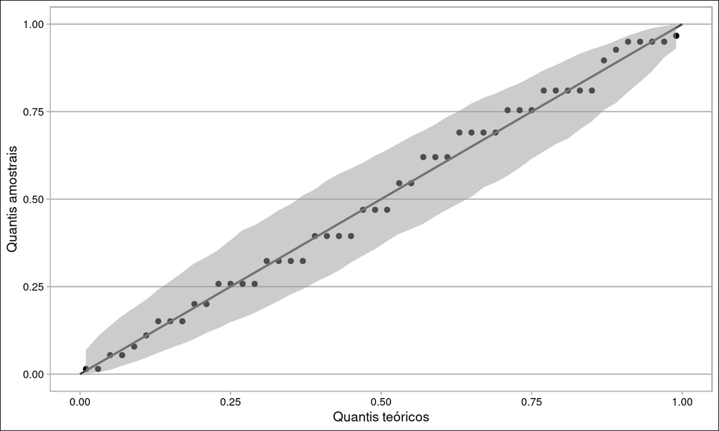

```r
ggplot(df_carros, aes(sample = vel)) +
  stat_pp_point() +
  stat_pp_line() +
  stat_pp_band() +
  theme_calc() +
  labs(x = "Quantis teóricos", y = "Quantis amostrais")
```

Então podemos usar regressão linear para este modelo. Vamos usar *validação cruzada* para decidir entre três modelos:

Vamos usar o pacote `modelr` do *framework* `tidyverse` para calcular validação cruzada:

- `cross_kfold(data, k)`: cria \(K\) partições da amostra.
- `mse()`: calcula o \(EP\).

## Validação cruzada

```r
particao <- crossv_kfold(df_carros, k = nrow(df_carros))

vc_linear <- particao$train |>
  map(~ lm(vel ~ 1 + dist, data = .x)) |>
  map2_dbl(particao$test, mse) |>
  mean()

vc_quadrado <- particao$train |>
  map(~ lm(vel ~ 1 + dist + I(dist^2), data = .x)) |>
  map2_dbl(particao$test, mse) |>
  mean()

vc_cubico <- particao$train |>
  map(~ lm(vel ~ 1 + dist + I(dist^2) + I(dist^3), data = .x)) |>
  map2_dbl(particao$test, mse) |>
  mean()

tab_vc <- tibble(
  modelo = c("Linear", "Quadrático", "Cúbico"),
  VC = c(vc_linear, vc_quadrado, vc_cubico)
)
```

| modelo | VC |
| --- | --- |
| Linear | 10,525 |
| Quadrático | 9,023 |
| Cúbico | 9,272 |

## Validação cruzada

```r
ajuste <- lm(vel ~ 1 + dist + I(dist^2), data = df_carros)
tidy(ajuste)
```

```
## # A tibble: 3 × 5
##   term        estimate std.error statistic     p.value
##   <chr>          <dbl>     <dbl>     <dbl>       <dbl>
## 1 (Intercept)  5.14     1.30          3.97 0.000244
## 2 dist         0.327    0.0547        5.98 0.000000286
## 3 I(dist^2)   -0.00153  0.000494     -3.09 0.00332
```

```r
glance(ajuste)
```

```
## # A tibble: 1 × 12
##   r.squared adj.r.squared sigma statistic  p.value    df logLik   AIC   BIC deviance df.residual  nobs
##       <dbl>         <dbl> <dbl>     <dbl>    <dbl> <dbl>  <dbl> <dbl> <dbl>    <dbl>       <int> <int>
## 1     0.710         0.698  2.91      57.6 2.30e-13     2  -123.  254.  261.     397.          47    50
```

## Validação cruzada

```r
info_geral <- augment(ajuste)
shapiro.test(info_geral$.std.resid)
```

```
##
##  Shapiro-Wilk normality test
##
## data:  info_geral$.std.resid
## W = 0.97958, p-value = 0.5345
```

```r
runs.test(info_geral$.std.resid)
```

```
##
##  Runs Test
##
## data:  info_geral$.std.resid
## statistic = -0.57155, runs = 24, n1 = 25, n2 = 25, n = 50, p-value = 0.5676
## alternative hypothesis: nonrandomness
```

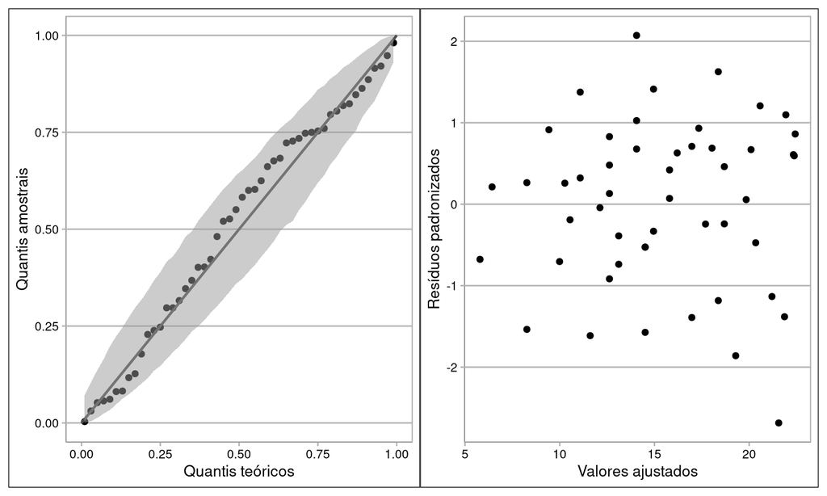

```r
plot_qqnorm  <- ggplot(info_geral, aes(sample = .std.resid)) +
  stat_pp_point() +
  stat_pp_line() +
  stat_pp_band() +
  theme_calc() +
  labs(x = "Quantis teóricos", y = "Quantis amostrais")
plot_residuo <- ggplot(info_geral) +
  geom_point(aes(.fitted, .std.resid)) +
  theme_calc() +
  labs(y = "Resíduos padronizados", x = "Valores ajustados")
plot_qqnorm | plot_residuo
```

## Validação cruzada

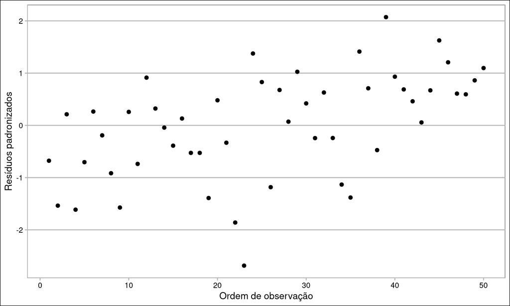

```r
ggplot(info_geral) +
  geom_point(aes(x = seq_along(.std.resid), y = .std.resid)) +
  labs(x = "Ordem de observação", y = "Resíduos padronizados") +
  theme_calc()
```